# Об алгоритмах подробнее

## Метод k ближайших соседей (k nearest neighbours)

Сначала рассмотрим общий принцип работы. Пусть у нас есть небольшой датасет с двумя классами элементов

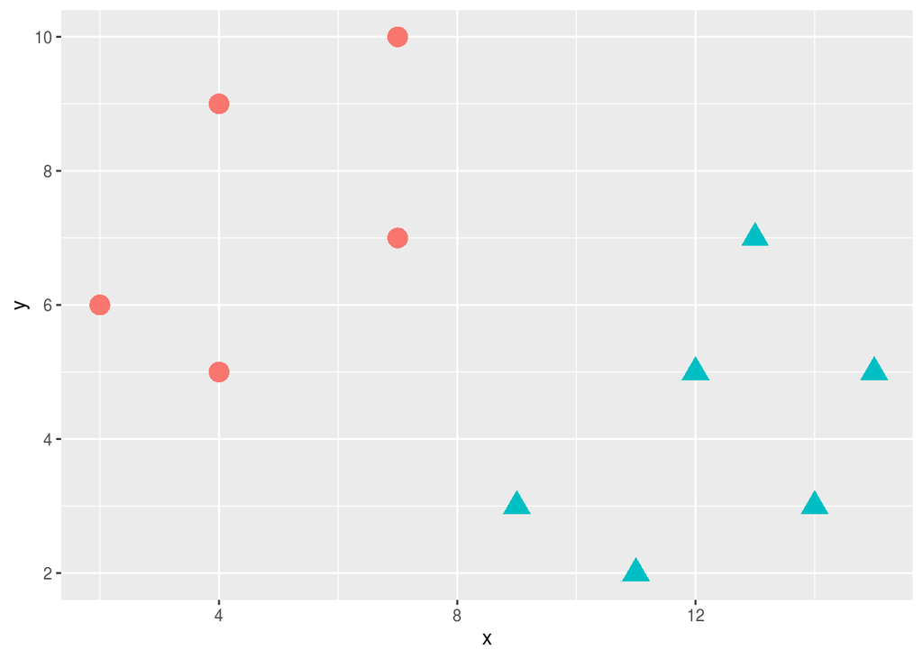

**1 ближайший сосед:** точка принадлежит к тому классу, что и ближайшая к ней точка. Ближайшая = расположенная на наименьшем расстоянии (расстояние чаще всего Евклидово, т.е. $\sqrt{(x_1-x_2)^2 + (y_1-y_2)^2}$).

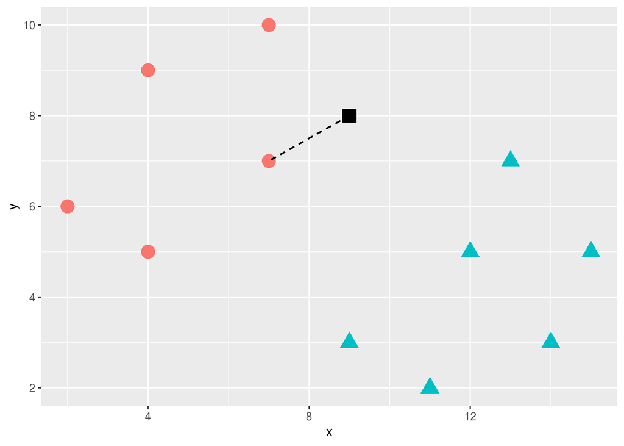

Итоговое разделение:

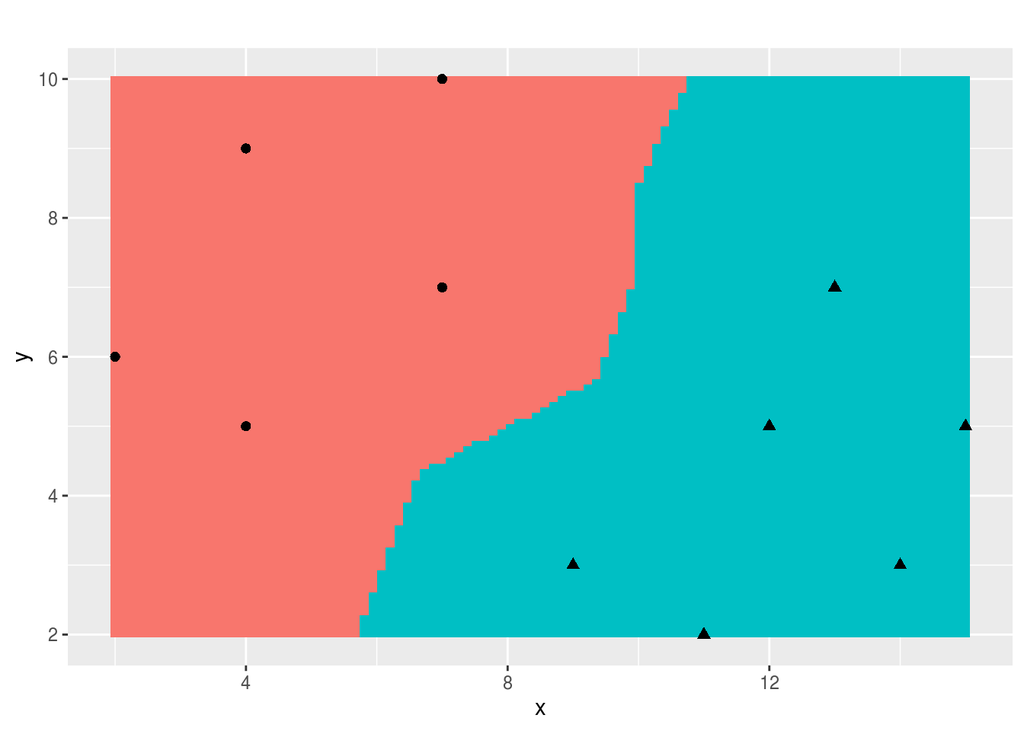

**k ближайших соседей:** точка принадлежит к тому классу, что и большинство из k ближайших к ней точек. Т.е. ищем k точек, расстояние до которых меньше, считаем долю каждого из классов среди этих точек и выбираем тот класс, доля которого больше. Например, для k = 3:

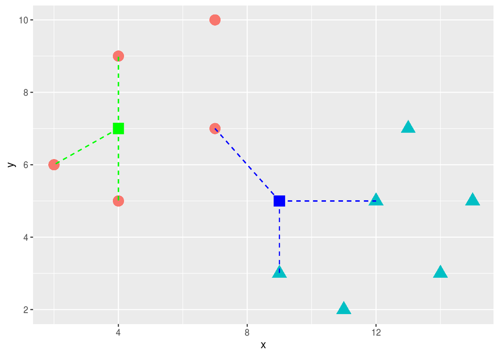

Для зеленой точки – из 3 ближайших соседей 3 красных и 0 голубых, значит относим к красным.

Для синей точки – из 3 ближайших соседей 1 красная и 2 голубых, значит относим к голубым.

Итоговое разделение:

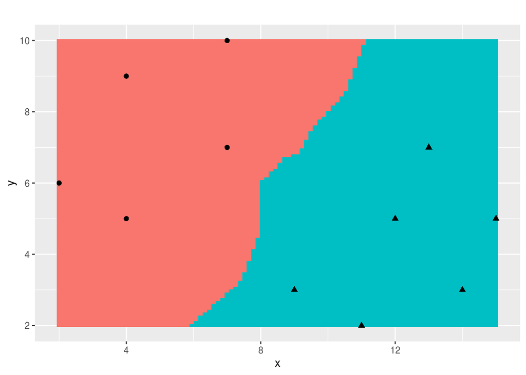

Что будет, если установить k = 11?

Как меняется результат при **увеличении k**? Рассмотрим на немного большем примере

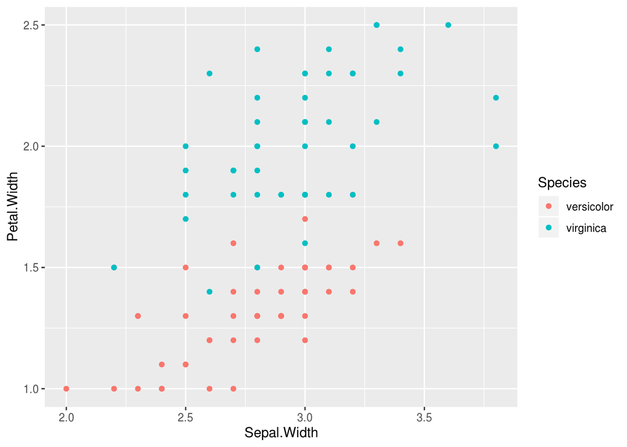

```r
iris <- filter(iris, Species != "setosa")
ggplot(data = iris) + geom_point(aes(x=Sepal.Width, y = Petal.Width, color = Species))
```

Для одного соседа:

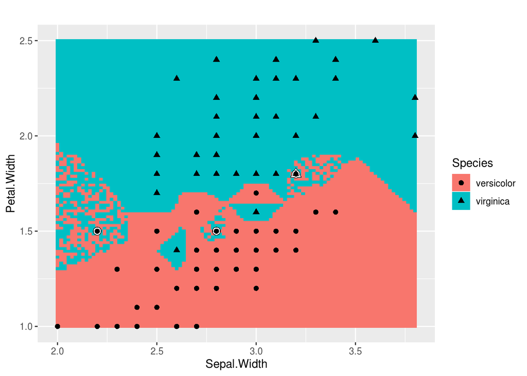

Для 3 соседей:

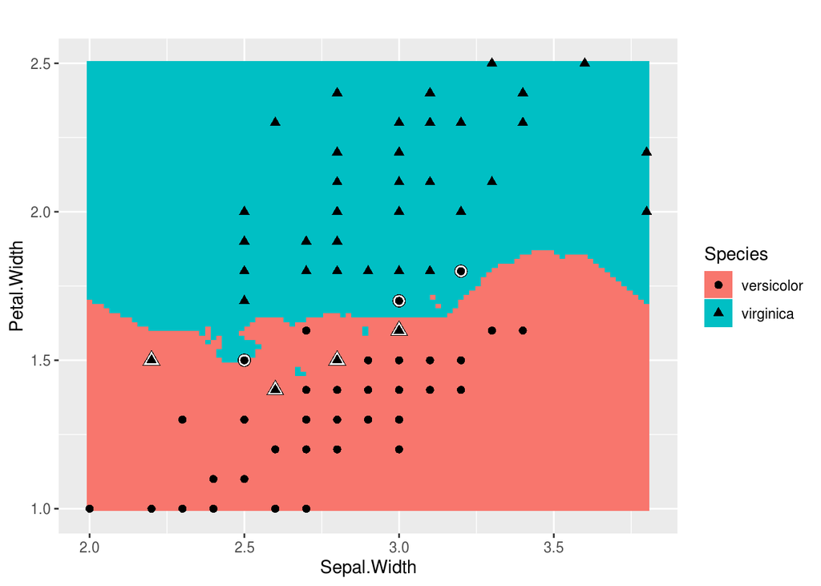

Для 5 соседей:

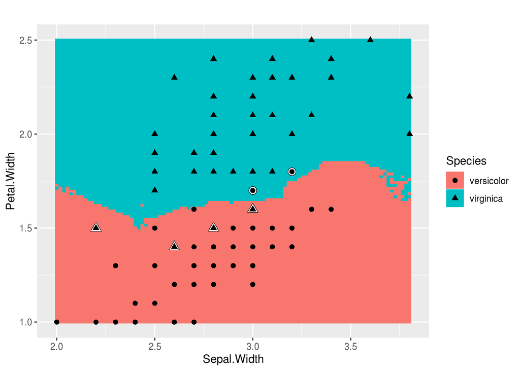

Для 10 соседей:

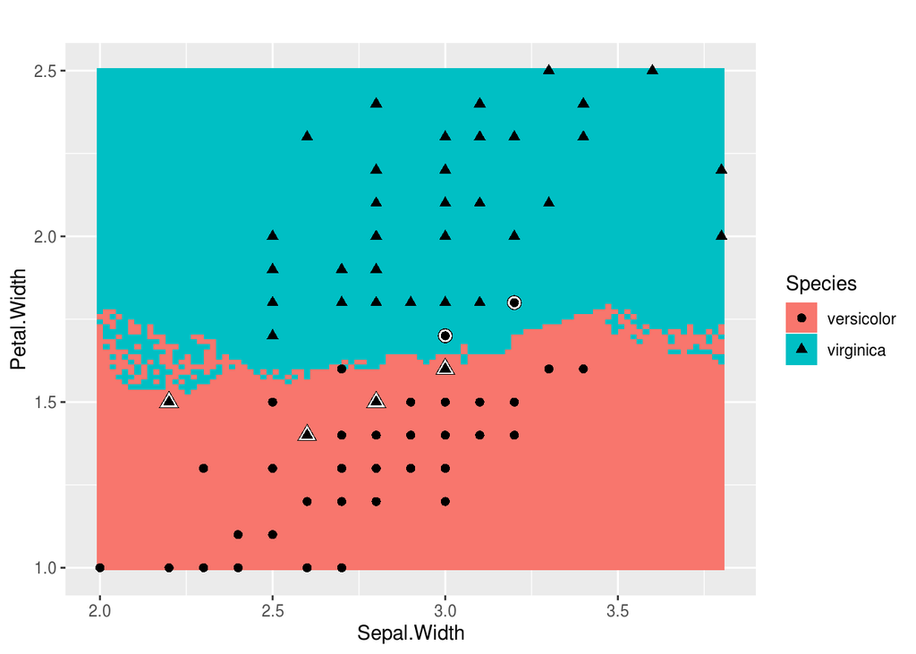

Для 25 соседей:

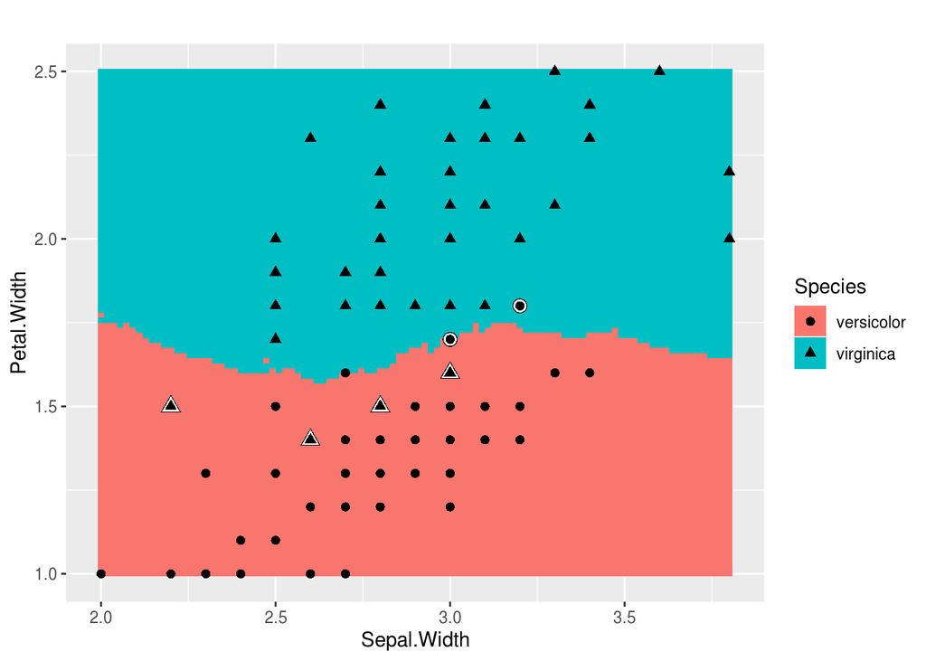

Чем больше k - тем более общую модель мы получаем. При небольших k разделение на классы больше “подогнано” к обучающим данным - при k = 1 точность на обучающей выборке равна 1 (ближайшая точка к любой точке – она сама), но на тестовой она уже существенно ниже. В целом зависимости можно представить следующим образом

Ошибка на обучающей выборке при изменении k

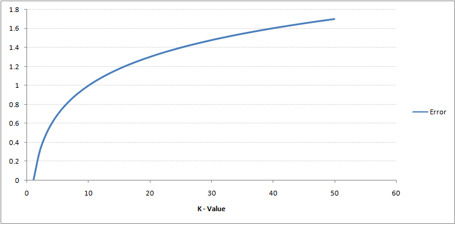

Ошибка на тестовой выборке при изменении k

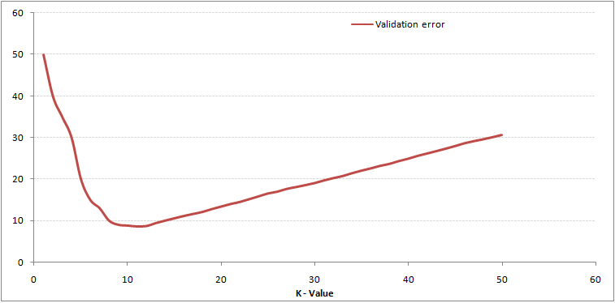

### Данные (рак предстательной железы)

Загружаем данные

```r
prCancer <- read.csv("~/shared/minor3_2019/1-KaggleML/data/Prostate_Cancer.csv")
```

Посмотрим на них

```r
str(prCancer)
```

```
## 'data.frame':    100 obs. of  10 variables:
##  $ id               : int  1 2 3 4 5 6 7 8 9 10 ...
##  $ diagnosis_result : Factor w/ 2 levels "B","M": 2 1 2 2 2 1 2 2 2 2 ...
##  $ radius           : int  23 9 21 14 9 25 16 15 19 25 ...
##  $ texture          : int  12 13 27 16 19 25 26 18 24 11 ...
##  $ perimeter        : int  151 133 130 78 135 83 120 90 88 84 ...
##  $ area             : int  954 1326 1203 386 1297 477 1040 578 520 476 ...
##  $ smoothness       : num  0.143 0.143 0.125 0.07 0.141 0.128 0.095 0.119 0.127 0.119 ...
##  $ compactness      : num  0.278 0.079 0.16 0.284 0.133 0.17 0.109 0.165 0.193 0.24 ...
##  $ symmetry         : num  0.242 0.181 0.207 0.26 0.181 0.209 0.179 0.22 0.235 0.203 ...
##  $ fractal_dimension: num  0.079 0.057 0.06 0.097 0.059 0.076 0.057 0.075 0.074 0.082 ...
```

У нас есть 8 параметров, характеризующих новообразование:

- Radius
- Texture
- Perimeter
- Area
- Smoothness
- Compactness
- Symmetry
- Fractal dimension

Переменная `diagnosis_result`, соответствующая диагнозу, имеет два значения:

- В = Benign (доброкачественное новообразование)
- M = Malignant (злокачественное новообразование)

## Обучающая и тестовая выборки

```r
set.seed(345)
pc.test.ind = sample(seq_len(nrow(prCancer)), size = nrow(prCancer)*0.3)
pc.test = prCancer[pc.test.ind,]
pc.main = prCancer[-pc.test.ind,]
```

Рассмотрим сначала всего два предиктора – периметр `perimeter` и коэффицент симметрии `symmetry`

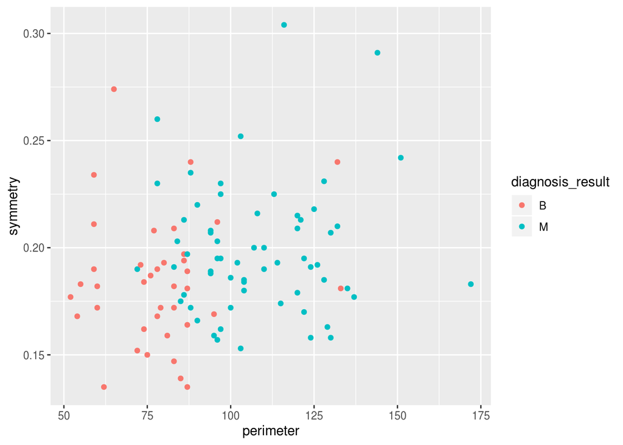

```r
ggplot(data = prCancer, aes(color = diagnosis_result)) + geom_point(aes(x=perimeter, y = symmetry))
```

```r
data.main <- dplyr::select(pc.main, diagnosis_result, perimeter, symmetry)
data.test <- dplyr::select(pc.test, diagnosis_result, perimeter, symmetry)
```

## Построение моделей

1 ближайший сосед

```r
library(class)
library(caret)
knn_model <- knn(train = select(data.main, -diagnosis_result),
                 test = select(data.test, -diagnosis_result),
                 cl=data.main$diagnosis_result)
```

Результаты на тестовой выборке

```r
confusionMatrix(knn_model,data.test$diagnosis_result)
```

```
## Confusion Matrix and Statistics
##
##           Reference
## Prediction  B  M
##          B  6  4
##          M  4 16
##
##                Accuracy : 0.7333
##                  95% CI : (0.5411, 0.8772)
##     No Information Rate : 0.6667
##     P-Value [Acc > NIR] : 0.286
##
##                   Kappa : 0.4
##
##  Mcnemar's Test P-Value : 1.000
##
##             Sensitivity : 0.6000
##             Specificity : 0.8000
##          Pos Pred Value : 0.6000
##          Neg Pred Value : 0.8000
##              Prevalence : 0.3333
##          Detection Rate : 0.2000
##    Detection Prevalence : 0.3333
##       Balanced Accuracy : 0.7000
##
##        'Positive' Class : B
##
```

График

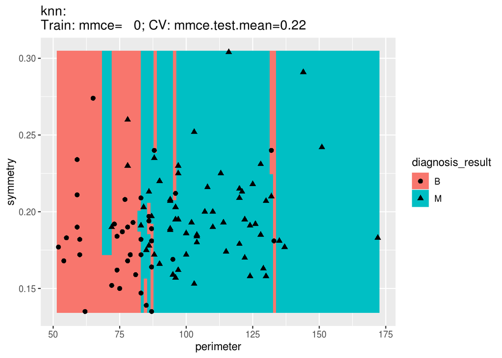

3 ближайших соседа

```r
knn_model <- knn(train = select(data.main, -diagnosis_result),
                 test = select(data.test, -diagnosis_result),
                 cl=data.main$diagnosis_result, k = 3)
```

Результаты на тестовой выборке

```r
confusionMatrix(knn_model,data.test$diagnosis_result)
```

```
## Confusion Matrix and Statistics
##
##           Reference
## Prediction  B  M
##          B  9  5
##          M  1 15
##
##                Accuracy : 0.8
##                  95% CI : (0.6143, 0.9229)
##     No Information Rate : 0.6667
##     P-Value [Acc > NIR] : 0.08384
##
##                   Kappa : 0.5909
##
##  Mcnemar's Test P-Value : 0.22067
##
##             Sensitivity : 0.9000
##             Specificity : 0.7500
##          Pos Pred Value : 0.6429
##          Neg Pred Value : 0.9375
##              Prevalence : 0.3333
##          Detection Rate : 0.3000
##    Detection Prevalence : 0.4667
##       Balanced Accuracy : 0.8250
##
##        'Positive' Class : B
##
```

График

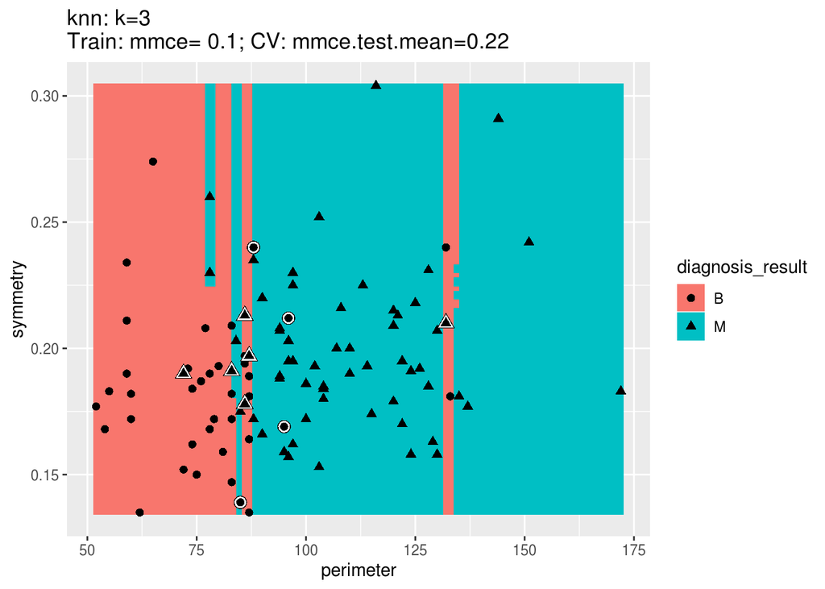

### Нормализация

**Обратите внимание:** используемые нами переменные имеют очень разные значения

```r
summary(prCancer$perimeter)
```

```
##    Min. 1st Qu.  Median    Mean 3rd Qu.    Max.
##   52.00   82.50   94.00   96.78  114.25  172.00
```

```r
summary(prCancer$symmetry)
```

```
##    Min. 1st Qu.  Median    Mean 3rd Qu.    Max.
##  0.1350  0.1720  0.1900  0.1932  0.2090  0.3040
```

Поэтому вклад в измерение расстояния у них очень разный: разница между самыми отдаленными значениями симметрии 0.169, а периметра – 120. Соответственно, для алгоритма при вычислении расстояния между точками периметр важнее (это видно и на графике – почти все разделение вертикальными линиями). Чтобы этого избежать, проводят нормализацию, т.е. приведение к единой шкале (традиционно к значениям от 0 до 1). Для этого нужно из каждой переменной вычесть ее минимальное значение и разделить на диапазон значений.

```r
smin <- min(prCancer$symmetry)
pmin <- min(prCancer$perimeter)
smax <- max(prCancer$symmetry)
pmax <- max(prCancer$perimeter)
prCancer$symmetry <-
  (prCancer$symmetry - smin)/(smax-smin)
prCancer$perimeter <-
  (prCancer$perimeter - pmin)/(pmax-pmin)
```

И не забыть повторить разделение на тестовую и обучающую выборки

```r
pc.test = prCancer[pc.test.ind,]
pc.main = prCancer[-pc.test.ind,]
```

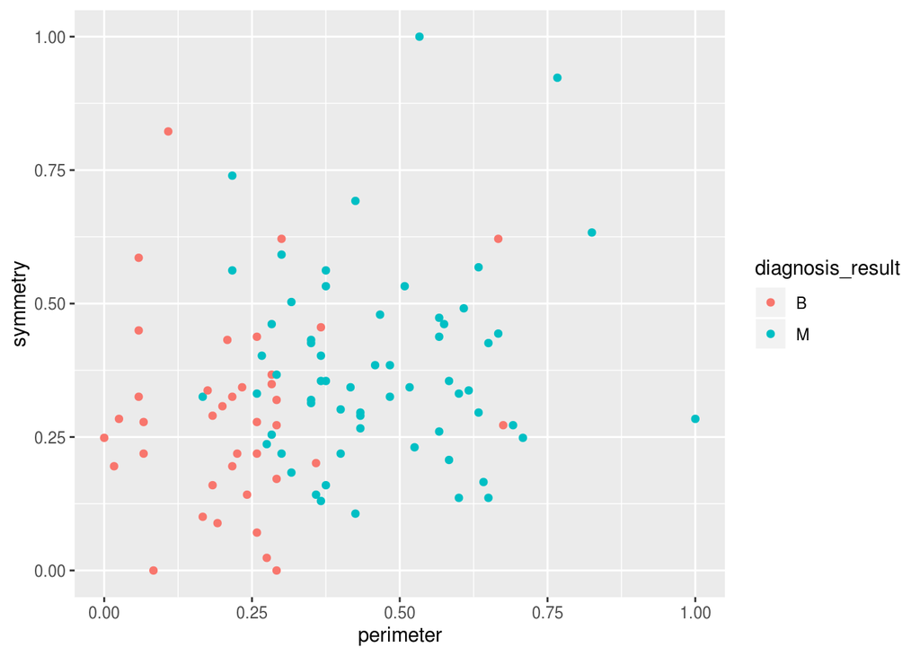

```r
ggplot(data = prCancer, aes(color = diagnosis_result)) + geom_point(aes(x=perimeter, y = symmetry))
```

```r
data.main <- dplyr::select(pc.main, diagnosis_result, perimeter, symmetry)
data.test <- dplyr::select(pc.test, diagnosis_result, perimeter, symmetry)
```

Новая модель

```r
knn_model <- knn(train = select(data.main, -diagnosis_result),
                 test = select(data.test, -diagnosis_result),
                 cl=data.main$diagnosis_result)
```

И новые результаты на тестовой выборке

```r
confusionMatrix(knn_model,data.test$diagnosis_result)
```

```
## Confusion Matrix and Statistics
##
##           Reference
## Prediction  B  M
##          B  8  3
##          M  2 17
##
##                Accuracy : 0.8333
##                  95% CI : (0.6528, 0.9436)
##     No Information Rate : 0.6667
##     P-Value [Acc > NIR] : 0.03545
##
##                   Kappa : 0.6341
##
##  Mcnemar's Test P-Value : 1.00000
##
##             Sensitivity : 0.8000
##             Specificity : 0.8500
##          Pos Pred Value : 0.7273
##          Neg Pred Value : 0.8947
##              Prevalence : 0.3333
##          Detection Rate : 0.2667
##    Detection Prevalence : 0.3667
##       Balanced Accuracy : 0.8250
##
##        'Positive' Class : B
##
```

График

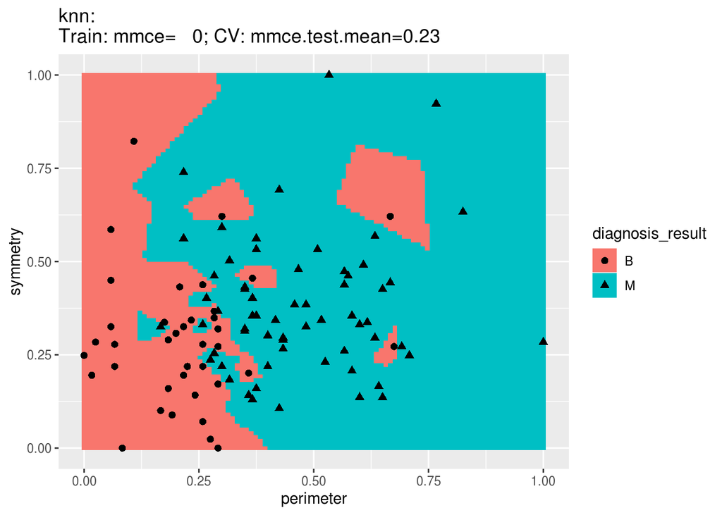

Результаты для другой реализации метода

```r
knn_model2 <- knn3(diagnosis_result~., data = data.main)
knn_pred <- predict(knn_model2, dplyr::select(data.test, -diagnosis_result), type = "class")
confusionMatrix(knn_pred, data.test$diagnosis_result)
```

```
## Confusion Matrix and Statistics
##
##           Reference
## Prediction  B  M
##          B  9  3
##          M  1 17
##
##                Accuracy : 0.8667
##                  95% CI : (0.6928, 0.9624)
##     No Information Rate : 0.6667
##     P-Value [Acc > NIR] : 0.01223
##
##                   Kappa : 0.7143
##
##  Mcnemar's Test P-Value : 0.61708
##
##             Sensitivity : 0.9000
##             Specificity : 0.8500
##          Pos Pred Value : 0.7500
##          Neg Pred Value : 0.9444
##              Prevalence : 0.3333
##          Detection Rate : 0.3000
##    Detection Prevalence : 0.4000
##       Balanced Accuracy : 0.8750
##
##        'Positive' Class : B
##
```

**Ваша очередь**:

- Какой прозноз согласно модели будет при значениях периметра 80 и симметрии 0.22? (для модели knn3)

```r
  (0.22 - smin)/(smax-smin)
```

```
## [1] 0.5029586
```

```r
  (80 - pmin)/(pmax-pmin)
```

```
## [1] 0.2333333
```

```r
new_data <- NULL
new_data <- as.data.frame(new_data)
new_data[1,1] <- 0.2333333
new_data[1,2] <- 0.5029586
colnames(new_data) <- c("perimeter","symmetry")
knn_pred <- predict(knn_model2, new_data, type = "class")
```

- Улучшится ли точность, если увеличить k? Какое значение k лучше выбрать?
- Улучшится ли точность, если добавить остальные предикторы?
- Сравните результаты при нормализации и без нее при включении всех предикторов

P.S.

```r
x <- data.frame(symmetry=(0.28-smin)/(smax-smin), perimeter=(100-pmin)/(pmax-pmin))
predict(knn_model2, x)
```